# Survey-to-Ecopath/Ecosim Pipeline

Code documentation: scripts, functions, inputs and outputs — for any GFCM GSA subset or user-defined region in the Mediterranean

Documentation generated with Claude

2026-09-10

# 1 Purpose of this document

This document describes a general-purpose R pipeline for turning MEDITS/ MEDIAS trawl-survey and catch data into input sheets for an Ecopath-with- Ecosim (EwE) model, for **any region in the Mediterranean Sea** — a single GFCM Geographical Sub-Area (GSA), any subset or the full set of GSAs, or a completely user-defined region (a bounding box or an arbitrary shapefile that doesn’t line up with GSA lines at all, e.g. a bay, an MPA, or a footprint spanning parts of several GSAs). It covers every script provided, what each one reads and writes, and every function in the shared library those scripts call.

The scripts as delivered are configured for the **Western Mediterranean** (GSA 1–11) as a **worked example** — this is what `01_survey_density_westmed.R`, `export_gsa_boundaries.R` and `fig_WMed_basemap.R` currently point at, and what a few reference tables (e.g. the MEDIAS Handbook area crosswalk) are currently populated for. The underlying mechanism — GSA-based selection via `FILTER_AREAS`, or an arbitrary region via `01_survey_density_custom.R` — is not Western-Med-specific; see Adapting this pipeline to a different region below for exactly what to change to point the same pipeline at another part of the Mediterranean.

All scripts read from and write to **one shared workbook**, `output/ecopath_ecosim_inputs.xlsx`, via two library functions designed for exactly this purpose:

- `upsert_workbook_sheets()` — adds/replaces named sheets, leaves every other sheet in the workbook untouched. Safe to call from any script, in any order, any number of times.
- `finalize_workbook_sheet_order()` — run **last**, after every upstream script has run at least once. Renames a couple of sheets (`FG_lookup` → `FG`, `References` → `PB_QB_References_`) and reorders every sheet into the final layout Ecopath/Ecosim expects.

Because of this design, the four numbered pipeline scripts are **order-independent with respect to the shared workbook** — except where a script’s own calculations literally need a file another script produced first (documented per-script below).

# 2 Data and code locations

- **Code** — every script and library file documented here lives in the **WestMed EwE GitHub repository** (`WMed_EwE`, cloned locally to what the scripts call `git_dir`). All shared-library `source()` calls (`lib_survey_fg_density_functions.R`, `lib_worms_taxonomy_lookup.R`, `lib_build_species_df_from_survey.R`) resolve against this repository’s `scripts/` folder.
- **Input data** — every raw survey, catch and reference file each script reads (`FG_WMed.xlsx`, `TM_list_(April_2019).xlsx`, MEDITS `TA.csv`/ `TB.csv`, MEDIAS `abundance.csv`/`biomass.csv`, `ASFIS_sp_2026.1.csv`, the catchability CSV, GFCM capture/reference CSVs) is read from the **WestMed EwE pCloud drive** (`EwE Western Med 2026`, mounted/synced locally to what the scripts call `pcloud_dir`), **not** from the GitHub repository — the repository holds code only, no raw data.
- **Outputs** — every CSV, plot, and the shared `ecopath_ecosim_inputs.xlsx` workbook are written to a local `out_dir` (not synced back to pCloud or GitHub by the scripts themselves).

Throughout this document, `<pcloud_dir>` means *the WestMed EwE pCloud drive* and `<git_dir>` means *the WestMed EwE GitHub repository* — both are plain local paths the top of each script resolves (hardcoded for one user, or picked interactively via `rstudioapi::selectDirectory()` for anyone else), not fixed locations baked into the code. Retargeting the pipeline to a different region (see Adapting this pipeline to a different region) does not require moving off pCloud/GitHub — only pointing `pcloud_dir`/ `git_dir` at that region’s own drive/repository, or adding that region’s data alongside the Western Med data in the same drive/repository.

**A note on the plots and column tables in this document:** this documentation was written without direct access to the WestMed EwE pCloud drive’s actual data files. The **column-reference tables** throughout are not guesses — they list exactly the column names each script’s own code reads (`select()`/`merge()`/`setnames()` calls, etc.), so they’re accurate regardless of the actual data values. The **figures**, however, are the pipeline’s own real output and only appear once you’ve generated them — see Populating the real figures below.

## 2.1 Populating the real figures

Several sections below embed a figure via a small `safe_include_graphics()` helper (defined in this document’s setup chunk). Each one checks for a file under `figures/` (a folder that must sit next to this `.Rmd`) and shows the real image if present, or a plain “not yet available” message with the exact script/output path to copy from if not — so this document always knits cleanly either way. To populate them for real:

1. Run the relevant script (named in each placeholder message) against the real WestMed EwE pCloud drive data.
2. Copy the named `.png` from that script’s `<out_dir>/plots/` into a `figures/` folder next to this `.Rmd`, keeping the same filename.
3. Re-knit.

Four **other** diagrams in this document (the pipeline flow, the FG-matching cascade, the workbook sheet assembly, and the PB/QB taxon dispatch diagrams) are a different kind of figure: **Mermaid flowcharts**, in the same style as `medbs_pipeline_methodology.qmd`’s own diagrams (same `flowchart LR` layout, the same gray/purple/teal/coral `classDef` palette). They show the code’s own logic — which function calls which, which sheet gets written by what, which fallback branch runs when — built directly from the script and library contents described here, not from any survey or model output. Because they’re plain text (Mermaid syntax rendered in-browser via `mermaid.js`, loaded from a CDN in this document’s setup), they contain no data values and no image files to go missing — unlike the four `safe_include_graphics()` placeholders above, they always render, with or without an internet connection to the pCloud drive. They do need an internet connection *to the Mermaid CDN* at view time (not render time) to draw the SVG in the browser; if you’d rather they render standalone with no external dependency, `rmarkdown::html_document(self_contained = TRUE)` still inlines the two `<script>` tags below the CSS chunk, so this only matters if that CDN is unreachable from wherever the HTML is opened.

# 3 Pipeline overview

The diagram below is a schematic of the actual script/function call structure documented in this document — which script produces which intermediate file, and which workbook sheets each one writes. It is not a plot of any survey data or model output (same diagram style as `medbs_pipeline_methodology.qmd`’s “Pipeline flow” section).

**Step 1 — pick ONE:**

- `01_survey_density_westmed.R` (MEDITS + MEDIAS, GFCM GSA areas), **or**
- `01_survey_density_custom.R` (MEDITS only, custom bbox/shapefile)

↓ produces `species_density_regional_combined.csv`, `strata_area_by_area.csv`, and sheets `FG_spp_Ecopath`, `Ecopath`, `Ecosim`, `FG_spp_Ecosim`, `FG` (renamed from `FG_lookup`), `traits_ewe`.

**Step 2:**

- `02_fao_catches.R` (reads Step 1’s `strata_area_by_area.csv`)

↓ produces sheets `Catches_Ecopath`, `Catches_Ecosim`.

**Step 3 — independent, can run anytime before Step 4:**

- `03_ecobase_query.R`

↓ produces `ecobase_literature_pb_qb_simple.csv` (optional Step 4 input).

**Step 4 — run last:**

- `04_pbqb_calc.R` (needs Step 1’s `species_density_regional_combined.csv`; optionally reads Step 2’s `fg_catch_timeseries_*.csv` and Step 3’s `ecobase_literature_pb_qb_simple.csv`)

↓ produces sheets `PB_QB`, `PB_QB_spp`, `Ecobase`, `References` (renamed to `PB_QB_References_`).

**Finally**, `finalize_workbook_sheet_order()` — called from whichever script runs last — reorders every sheet into the final layout:

↓ `output/ecopath_ecosim_inputs.xlsx`, final, ordered, ready for Ecopath import.

Two more files are **not** part of the numbered pipeline, but support it:

- `lib_survey_fg_density_functions.R` and `lib_worms_taxonomy_lookup.R` and `lib_build_species_df_from_survey.R` — shared library files, `source()`’d by the numbered scripts, no top-level driver code of their own.
- `export_gsa_boundaries.R` and `fig_WMed_basemap.R` — standalone cartography utilities, not required by the numbered pipeline. `export_gsa_boundaries.R` in particular produces the GeoJSON embedded in `medbs_pipeline_methodology.qmd`’s interactive map.

# 4 Run order and dependencies

[output not shown]

`finalize_workbook_sheet_order()` should be called at the end of whichever script ran *last* in a given session (each of the numbered scripts already does this itself at its own final step).

# 5 Script 1a — `01_survey_density_westmed.R`

**Role:** Pipeline Step 1 of 4, GFCM-GSA-based version — the general mechanism for **any GSA subset anywhere in the Mediterranean**, not just the Western Med. Run this **or** `01_survey_density_custom.R`, not both, as Step 1. No dependency on the other numbered scripts; `02_fao_catches.R` and `04_pbqb_calc.R` both require this step’s output to exist first.

Runs two independent surveys over the same GSAs/FG scheme (MEDITS bottom trawl + MEDIAS acoustic) and combines both into one set of Ecopath/Ecosim sheets, rather than producing separate MEDIAS sheets. As delivered it’s configured for the Western Med (GSA 1–11, via `FILTER_AREAS <- 1:11`) as a worked example; retargeting it to a different GSA subset elsewhere in the Mediterranean — the Adriatic, the Aegean, the whole basin — is a matter of changing that one line and the region-specific reference tables listed in Adapting this pipeline to a different region.

## 5.1 Inputs

| File | Format | Role |
| --- | --- | --- |
| `<pcloud_dir>/data/FG_WMed.xlsx`, sheet 4 | xlsx | Species → Functional Group reference (`dataframe2`: `ESPECIE`→`ScientificName`, `GF`→`FG_num`, `FG_name`) |
| `<pcloud_dir>/data/FG_WMed.xlsx`, sheet `traits_ewe` | xlsx | Per-species life-history/ecology traits |
| `<pcloud_dir>/.../TM_list_(April_2019).xlsx` | xlsx | MEDITS species-code → scientific-name lookup |
| `<pcloud_dir>/.../Demersal/TA.csv` | csv | MEDITS haul/sample metadata (position, depth, gear, swept-area inputs) |
| `<pcloud_dir>/.../Demersal/TB.csv` | csv | MEDITS catch-per-haul data |
| `<pcloud_dir>/.../Acoustic/abundance.csv`, `biomass.csv` | csv | MEDIAS acoustic-survey raw records |
| `<pcloud_dir>/data/ASFIS_sp_2026.1.csv` | csv | FAO ASFIS species code list (MEDIAS species-code → scientific name) |
| `<pcloud_dir>/data/catchability_factors_ecotrans_medits_2021_spp.csv` | csv (optional) | Per-species catchability correction factors (q); skipped with a message if absent |
| GFCM GSA shapefile | auto-downloaded zip from `gfcmsitestorage.blob.core.windows.net/website/5.Data/ArcGIS/GFCM_GSA.zip` | Study-area polygons (`area_shp`); `SMU_CODE` 111/112 (W/E Sardinia) merged into GSA 11 |
| NOAA bathymetry | auto-downloaded via `marmap::getNOAA.bathy()` inside `compute_strata_area_by_area()` | Depth-stratum area calculation |

`FILTER_AREAS <- 1:11` (this example’s Western Med GSAs — set to any GSA number or set of GSA numbers, anywhere in the GFCM area, to retarget the whole script to a different region), `YEAR_ECOPATH <- 1994:1996`, `TS_YEARS <- 1995:2023`, `STRATA <- TRUE`, `DROP_OUTLIERS <- FALSE`, `NORMALIZE_TS <- TRUE`.

### 5.1.1 Column reference — key input files

Columns as actually referenced by the code (from the `<pcloud_dir>` files above). Not every column in the real file is necessarily listed — only the ones the script reads.

**`FG_WMed.xlsx`, sheet 4** (→ `dataframe2`, the species→FG master):

| Column | Renamed to | Meaning |
| --- | --- | --- |
| `ESPECIE` | `ScientificName` | Species scientific name |
| `GF` | `FG_num` | Functional Group number |
| `FG_name` | `FG_name` | Functional Group name |

**`FG_WMed.xlsx`, sheet `traits_ewe`** (alternating “N: Group Name” header rows / species data rows — see Script 1a Step 10 below):

| Column (original header) | Renamed to |
| --- | --- |
| *(unnamed index column)* | `row_index` |
| `Species` | `Species_col` |
| `Organism` | `Organism` |
| `Ecology` | `Ecology` |
| `Occurrence status` | `Occurrence_status` |
| `Biomass contribution` | `Biomass_contribution` |
| `Catch contribution` | `Catch_contribution` |
| `IUCN conservation status` | `IUCN_conservation_status` |
| `Exploitation status` | `Exploitation_status` |
| `Vulnerability index (?)` | `Vulnerability_index` |
| `Mean length (?)` | `Mean_length` |
| `Max length (?)` | `Max_length` |
| `Mean weight (?)` | `Mean_weight` |
| `Mean life span (year)` | `Mean_lifespan_years` |

**`TM_list_(April_2019).xlsx`, sheet 1 (skip first 2 rows)** — the code locates its two needed columns by regex rather than a fixed name, since the exact header text has drifted between file versions: a column matching `/MEDITS/i` (the MEDITS species code) and a column matching `/Scientific/i` (the scientific name).

**MEDITS `TA.csv`** (haul/sample metadata):

| Column | Used for |
| --- | --- |
| `country`, `area`, `vessel`, `year`, `haul_number`, `month`, `day` | Built into `SampleID` (concatenated, `_`-separated) |
| `distance` | Trawl distance towed → swept area |
| `wing_opening` | Trawl wing opening (decimetres) → swept area |
| `shooting_depth`, `hauling_depth` | Averaged into `mean_depth` |
| `shooting_latitude`, `shooting_longitude` | DDMM.mmm format — converted to decimal degrees |
| `shooting_quadrant` | Present but **not used** — flagged in the code as an unresolved caveat around hemisphere sign |

**MEDITS `TB.csv`** (catch-per-haul data):

| Column | Used for |
| --- | --- |
| `country`, `area`, `vessel`, `year`, `haul_number`, `month`, `day` | Built into `SampleID`, joined against `TA.csv` |
| `genus`, `species` | Concatenated into `species_code`, joined against `TM_list` |
| `ptot` | Total catch weight (grams; negative values treated as `NA`, converted to tonnes) |

**MEDIAS `abundance.csv` / `biomass.csv`** (acoustic survey raw records):

| Column | Used for |
| --- | --- |
| `country`, `year`, `species` | Grouping key for aggregation |
| `area` | Text field containing a GSA number, extracted via regex (`\d+`) |
| `sex` | Filtered to `"C"` (combined sexes) when present |
| `lengthclass*` (many columns) | Summed row-wise into a single `total_value` (negative values treated as missing) |

**`ASFIS_sp_2026.1.csv`** (FAO species reference list):

| Column | Used for |
| --- | --- |
| `Alpha3_Code` | MEDIAS species code → joined against `abundance`/`biomass` |
| `Scientific_Name` | Resolved scientific name |
| *(also present: `ISSCAAP_Group`, `Taxonomic_Code`, `English_name`, …)* | Not read by this pipeline |

**Catchability CSV** (`catchability_factors_ecotrans_medits_2021_spp.csv`, optional):

| Column | Renamed to | Meaning |
| --- | --- | --- |
| `species` | `ScientificName` | Species scientific name |
| `q_FACTOR` | `q` | Catchability correction factor |

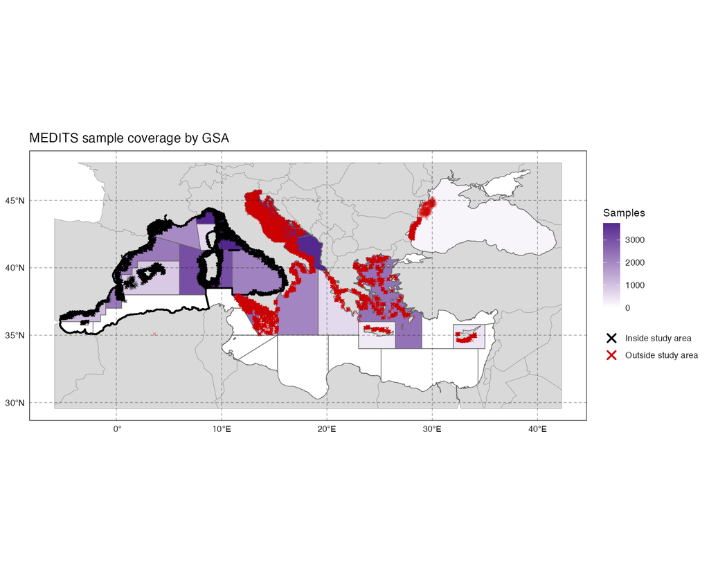

plot_sample_map() output — MEDITS sample coverage by area.

## 5.2 Processing steps

1. **Config** — resolve `out_dir`/`pcloud_dir`/`git_dir`, download/cache the GSA shapefile, source `lib_survey_fg_density_functions.R` and `lib_worms_taxonomy_lookup.R`.
2. **Load MEDITS data** — read `TA.csv`/`TB.csv`, compute swept area (`distance × wing_opening_m / 1e6`, wing opening in decimetres), convert DDMM.mmm lat/lon to decimal degrees, fix the Alboran Sea (GSA 1–3) longitude sign — a Western-Med-specific correction, harmless (a no-op) if your `FILTER_AREAS` doesn’t include GSA 1–3 — reshape into the standardized `dataframe1`/`dataframe2` format. Runs `validate_survey_data()` and `plot_sample_map()` (→ `survey_sample_coverage_map.png`, `survey_sample_coverage_map_by_year.png`).
3. **FG matching (Steps 3–4)** — `prepare_fg_lookup()` → `match_species_to_fg()` → `match_nominate_subspecies_fg()` → manual overrides (species codes absent from the MEDITS taxonomic list, e.g. `ARGRACU`→*Argyropelecus aculeatus*) → `fallback_match_fg_by_taxonomy()` (Genus→Family→Order→Class→Phylum) → `apply_seed_fg_rules()` (FGs with zero reference species, e.g. Holothuroidea→“Sea cucumbers”) → `summarize_unresolved_species()` → `survey_unmatched_for_manual_review.csv`.
4. **Densities (Step 5)** — `match_samples_to_area()`, `assign_depth_stratum()`, `compute_sample_densities()`, restrict to `FILTER_AREAS`, `apply_catchability_correction()` (if the catchability CSV exists), `remove_sample_outliers()` (→ `survey_outliers_flagged.csv` if any flagged), `compute_fg_densities_by_stratum()`.
5. **Strata/area weighting (Steps 6–7)** — `compute_strata_area_by_area()` (cached to `strata_area_by_area.csv`), `weight_by_strata()`, `weight_by_area()`, `compute_species_densities_by_stratum()`, `weight_species_by_area()`.
6. **MEDITS plots (Step 8)** — `plot_fg_timeseries_by_area()`, `plot_fg_timeseries_regional()`, `plot_strata_profile()` → `survey_fg_density_timeseries.png`, `survey_fg_density_timeseries_regional.png`, `survey_fg_depth_strata_profile.png`.

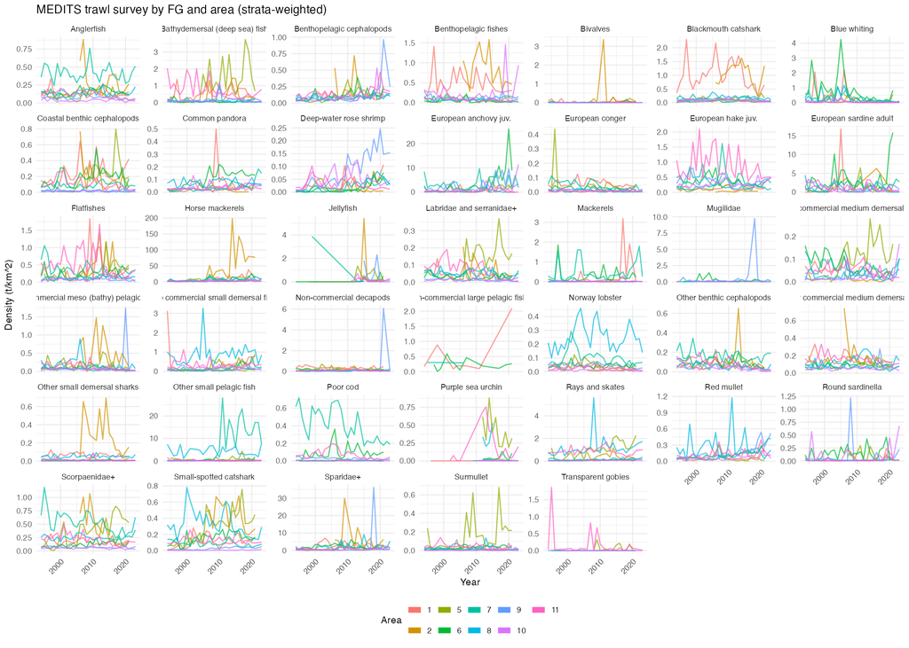

   plot_fg_timeseries_by_area() output — MEDITS trawl survey density by FG and area (strata-weighted).

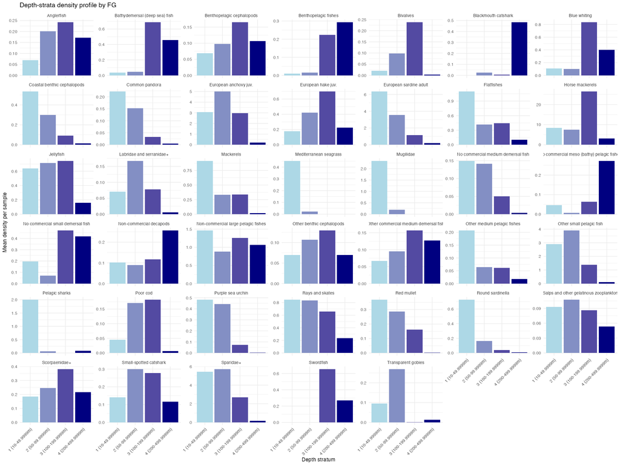

   plot_strata_profile() output — raw per-sample density across depth strata, by FG.

7. **MEDIAS acoustic survey (Step 9, sub-steps 9a–9g)** — load and collapse raw abundance/biomass records, map species codes via ASFIS, match to FG the same way as MEDITS, attach area (MEDIAS Handbook Table 1, hand-keyed `MEDIAS_HANDBOOK_AREAS` — as delivered this table only has Western Med entries, since that’s this example’s scope; extending to another region means adding that region’s own Handbook rows, with a bathymetry-derived 10–200 m fallback via `compute_strata_area_by_area()` covering any country/GSA combination the table doesn’t have a row for), compute region-wide FG and species density, then **combine MEDITS + MEDIAS** into one FG-level and one species-level table (averaged on Year/FG or Year/species overlap, overlaps flagged/printed). Outputs: `medias_fg_annual_density_by_area.csv`, `medias_fg_annual_density_regional.csv`, `medias_fg_biomass_density_timeseries_regional.png`, `medias_fg_abundance_density_timeseries_regional.png`, `species_density_regional_combined.csv` (**contract file** — read by `lib_build_species_df_from_survey.R` for `04_pbqb_calc.R`).
8. **Excel export (Step 10)** — `survey_fg_annual_index.csv`, `survey_fg_annual_index_regional_combined.csv`, then `export_ecopath_ecosim_excel()` writes sheets `FG_spp_Ecopath`, `Ecopath`, `Ecosim`, `FG_spp_Ecosim` into `ecopath_ecosim_inputs.xlsx`. **Also writes a `PB_QB_spp` scaffold** — reusing `FG_spp_Ecopath`’s own `Species`/ `FG_num`/`Density`/`prop_sp_fg` (renamed to `PB_QB_spp`’s convention: `Biomass`, `prop_biomass_FG`), with `PB`/`prop_biomass_PB`/`QB`/ `prop_biomass_QB` all blank and a `Note` column — so `PB_QB_spp` exists in the workbook after this script alone, without needing `04_pbqb_calc.R` (Step 4) to have run first. This function has no PB/QB computation of its own (that’s entirely Step 4’s, from life-history parameters, not survey density), so the scaffold’s numbers are genuinely blank, not estimated. Running Step 4 afterward replaces the scaffold with the real sheet automatically (`upsert_workbook_sheets()` always fully replaces a same-named sheet). Guarded against clobbering the other way: if `PB_QB_spp` already has real (non-`NA`) `PB` values — i.e. Step 4 already ran against this exact workbook — re-running this script leaves it untouched rather than overwriting it with a blank scaffold again.
9. **Complete `FG_spp_Ecopath`/`FG_lookup` (Step 11)** — union of observed + reference-catalog species, zero-fill species with no base-year density, attach taxonomy, defensive check for FGs with no species at all. Written via `upsert_workbook_sheets()`.
10. **`traits_ewe` sheet (Step 12)** — parse `FG_WMed.xlsx`’s `traits_ewe` sheet (alternating “N: Group Name” header rows / species rows, fill-down logic), reconcile against `dataframe2`, flag naming-variant and missing-traits species. Written via `upsert_workbook_sheets()`.
11. **Finalize sheet order (Step 13)** — `finalize_workbook_sheet_order()`.

## 5.3 Outputs

- **CSVs** (in `out_dir`): `survey_sample_coverage_map.png` and other plot PNGs (in `out_dir/plots`), `survey_unmatched_for_manual_review.csv`, `survey_outliers_flagged.csv`, `strata_area_by_area.csv`, `medias_fg_annual_density_by_area.csv`, `medias_fg_annual_density_regional.csv`, `species_density_regional_combined.csv`, `survey_fg_annual_index.csv`, `survey_fg_annual_index_regional_combined.csv`.
- **Workbook** `ecopath_ecosim_inputs.xlsx`, sheets written/updated: `FG_spp_Ecopath`, `Ecopath`, `Ecosim`, `FG_spp_Ecosim`, `FG_lookup` (renamed to `FG`), `traits_ewe`, and `PB_QB_spp` (scaffold, unless it already has real data from `04_pbqb_calc.R`).

# 6 Script 1b — `01_survey_density_custom.R`

**Role:** Alternative Step 1, for **any study area anywhere in the Mediterranean that doesn’t line up with GSA boundaries** — a single custom bounding box or shapefile (e.g. one EwE model’s own footprint, a bay, an MPA, or a region spanning parts of several GSAs, in any part of the basin). This is the general-purpose route for a fully user-defined region; Script 1a above is the general-purpose route for any GSA-aligned region instead. Run this **instead of** `01_survey_density_westmed.R`, never both. MEDITS-only — does not run the MEDIAS acoustic survey.

Structurally identical to `01_survey_density_westmed.R` for the MEDITS loading and FG-matching stages (Steps 1–4 use the exact same shared-library functions). What’s genuinely different:

- **`AREA_NAME`** — a user-supplied label for this custom study area (typed interactively via `rstudioapi::showPrompt()`, or hardcoded for the `daniel` user). Used to build a **dedicated output subfolder** (`out_dir/<AREA_NAME>/`) and to suffix every output filename via helper functions `af()`/`pf()`, so two different custom-region runs (different `AREA_NAME`s) never collide or overwrite each other’s outputs, and never collide with `01_survey_density_westmed.R`’s own `out_dir`.
- **Study-area definition (Step 1b)** — `CUSTOM_AREA_TYPE <- "bbox"` (a rectangle defined by `CUSTOM_BBOX <- c(xmin, xmax, ymin, ymax)`), `"shapefile"` (an arbitrary `sf` polygon read via `st_read()`), or **`"gsa"`** (one or more GFCM GSAs, picked out of the same GSA shapefile `01_survey_density_westmed.R` downloads, via `CUSTOM_GSA_IDS <- c(...)` — e.g. a single GSA, or a different regional grouping than that script’s fixed `1:11` Western-Med range). For `"bbox"`/`"shapefile"` the result is a single-feature `area_shp` with `AREA_ID_COL = "area_id"`, always `area_id = 1` — there is no GSA sub-division inside a custom region unless the user builds one. For `"gsa"`, `area_shp` can have **one row per selected GSA**, each keeping its own `gsa_num` as `area_id` (same convention as Script 1a), so a multi-GSA custom region is NOT forced down to a single `area_id = 1`.
- **`AreaID` is derived spatially** for `"bbox"`/`"shapefile"`, not read off MEDITS’ own `area` (GSA) column — every sample gets `AreaID = 1`, then `filter_samples_by_area()` drops everything outside the custom boundary. For `"gsa"`, `AreaID` follows the selected GSA(s) directly, same as Script 1a.
- **Strata-area computation (Step 6)** — `compute_strata_area_by_area()` called with `area_ids = 1` for `"bbox"`/`"shapefile"` (a single custom polygon), or with the selected `CUSTOM_GSA_IDS` for `"gsa"` (one or more named GSAs) — the function itself is agnostic to this distinction either way.

**Exception to the `AREA_NAME` filename-suffixing rule:** three files stay at plain, unsuffixed names on purpose, because `02_fao_catches.R` and `04_pbqb_calc.R` read them by that exact fixed name regardless of which Step-1 script produced them: `species_density_regional_combined.csv`, `ecopath_ecosim_inputs.xlsx`, `strata_area_by_area.csv`. The dedicated `AREA_NAME` subfolder is what keeps these three from colliding with another run’s copies.

## 6.1 Inputs

Same as `01_survey_density_westmed.R` minus the MEDIAS/ASFIS/GSA-shapefile inputs, plus (for `CUSTOM_AREA_TYPE = "shapefile"`) a user-supplied boundary shapefile.

## 6.2 Processing steps

Steps 1–5 mirror `01_survey_density_westmed.R` (see above) using the custom `area_shp`. Steps 6–12 are the same Excel-export / `FG_spp_Ecopath` / `traits_ewe` / sheet-order-finalization logic, applied to a single-area result. (Since this script skips MEDIAS, its `species_density_regional` table is MEDITS-only — no MEDITS+MEDIAS averaging step.)

## 6.3 Outputs

Same file set and workbook sheets as `01_survey_density_westmed.R` (see above), written to `out_dir/<AREA_NAME>/` with most filenames suffixed `_<AREA_NAME>`, except the three contract files listed above which stay unsuffixed.

# 7 Script 2 — `02_fao_catches.R`

**Role:** Pipeline Step 2 of 4. **Requires** Step 1 to have already run — it reads `strata_area_by_area.csv` (written by Step 1) to convert catch totals into a t/km² density comparable to Biomass. Running this before Step 1 fails with a clear “file not found” error pointing back to Step 1.

Config-driven catch-data loader: one `DATASETS` registry entry per source format, so `GFCM_2025` and (a currently-commented-out) `FAO_2026` share one processing path (`format = "gfcm_regional"`), while `FAO_2020` (`format = "legacy_excel"`) is handled separately as a genuinely different file layout. `DATASET_VERSION <- "GFCM_2025"` is the active, confirmed, working source; `FAO_2020` is present but its file location is **unconfirmed** on disk.

## 7.1 Inputs

| File | Format | Role |
| --- | --- | --- |
| `<git_dir>/data/raw/FI_Regional_2025.1.0/GFCM_Capture_Quantity.csv` | csv | Raw GFCM catch quantities |
| `.../CL_FI_SPECIES_GROUPS.csv` | csv | Species code → name reference (also auto-downloaded from FAO’s open-data catalog if not found under `pcloud_dir`) |
| `.../CL_FI_COUNTRY_GROUPS.csv` | csv | Country code → name reference |
| `.../CL_FI_WATERAREA_DIVISION.csv` | csv | FAO/GFCM division code → name reference; catches filtered to divisions `37.1.1`/`37.1.2`/`37.1.3` |
| `<pcloud_dir>/data/FG_WMed.xlsx`, sheet 4 | xlsx | Species → FG reference, same as Script 1 |
| `strata_area_by_area.csv` | csv | **From Step 1.** Total study-area km² for the density conversion |

### 7.1.1 Column reference — key input files

**`GFCM_Capture_Quantity.csv`** (raw catch, `<git_dir>/data/raw/FI_Regional_2025.1.0/`):

| Column | Used for |
| --- | --- |
| `SPECIES.ALPHA_3_CODE` | Joined against `CL_FI_SPECIES_GROUPS.csv` |
| `COUNTRY.UN_CODE` | Joined against `CL_FI_COUNTRY_GROUPS.csv` |
| `DIVISION.CODE` (`area_code_col`) | Joined against `CL_FI_WATERAREA_DIVISION.csv`; filtered to `37.1.1`/`37.1.2`/`37.1.3` (Western Med divisions — change for a different region) |
| `MEASURE` | Filtered to `"Q_tlw"` (live-weight tonnes) |
| `PERIOD` | Year |
| `VALUE` | Catch quantity |

**Reference CSVs** (same folder):

| File | Columns used |
| --- | --- |
| `CL_FI_SPECIES_GROUPS.csv` | `3A_Code` (species code) → `Name_En` (species name) |
| `CL_FI_COUNTRY_GROUPS.csv` | `UN_Code` → `Name_En` (country name) |
| `CL_FI_WATERAREA_DIVISION.csv` | `Code` (`area_join_col`) → `Name_En` (division name) |

**`FAO_2020` legacy Excel** (`format = "legacy_excel"`, alternate/unconfirmed source):

| Column | Renamed to |
| --- | --- |
| `Species (scientific name)` | `Species` |
| `Area (FAO division)` | `Division` |
| `Area (FAO subarea)` | `Subarea` — filtered to `"Western Med (37.1)"` |
| `Year`, `Quantity`, `Country` | used as-is |

## 7.2 Processing steps

1. **Config + dataset loading** — resolve directories, `load_gfcm_regional()` merges capture/species/country/area reference CSVs, filters to Western Med divisions, `MEASURE == "Q_tlw"`, `PERIOD >= 1995`. Builds `country_ts`/`species_ts` (Year × Country/Species × Division × Catch).
2. **Plots + audit CSVs** — country- and species-level catch time series (`country_catch_timeseries.png`, `species_catch_timeseries.png`), `unmatched_species_FG_assignment.csv`, `westmed_species_timeseries.csv`.
3. **Species → FG matching pipeline** (inline, Steps 0–4, same safety philosophy as Script 1’s taxonomy fallback — a query is only auto-resolved if it maps to exactly **one** distinct FG, otherwise flagged ambiguous and never guessed):
   - Step 1: direct match (catch-record species text literally equals an `FG_name`).
   - Step 2: common name → scientific name via `rfishbase::common_names()` (queried **for** the known species list, not searched from all of FishBase — avoids cross-matching an unrelated species that happens to share a common name).
   - Step 3: FAO genus-level fallback for NEI/aggregate categories (e.g. “Sardinellas nei” → genus *Sardinella*).
   - Step 4: word-containment fallback (full token containment only).
   - Manual overrides (e.g. “Turbot” → *Scophthalmus maximus*, correcting a wrong FishBase common-name entry).
   - A catch-total sanity check confirms no species record is double-counted across matching stages.
   - Output: `species_fg_matched.csv` (one row per species, `status` = resolved/unresolved, `match_method`).
4. **FG-level Year timeseries** — joins `species_ts` (has Year, no FG) against `species_fg_matched.csv`’s Species→FG mapping, re-aggregates to Year × FG. Output: `fg_catch_timeseries_<DATASET_VERSION>.csv` (landings-only, **not** confirmed to include discards — read by `04_pbqb_calc.R`’s optional `FG_YIELD_SOURCE = "fg_catch_csv"` path).
5. **Add `Catches_Ecopath`/`Catches_Ecosim` to the workbook** — reads `strata_area_by_area.csv`, sums to a total study-area km², calls `add_catches_to_ecopath_workbook()`. **Known, documented limitation:** GFCM Divisions 37.1.1–37.1.3 cover GSA 1–11 **plus** GSA 12 (Northern Tunisia), which the survey’s `FILTER_AREAS` does not include — the catch density is therefore a slight overestimate relative to the Biomass area (GFCM’s Division-resolution reporting can’t isolate GSA 12’s specific contribution to subtract it out).

**Not implemented — no fleet or gear disaggregation anywhere in this script.** `GFCM_Capture_Quantity.csv` (the actual, confirmed source above) resolves only to Country × Species × Division × Year — this is GFCM’s STATLANT-derived aggregate capture-production product, not its Operational-Unit-level data. GFCM *does* collect catch/effort broken down by **Operational Unit** (fleet segment × ISSCFG gear code × GSA), via the DCRF’s Task 2 (Catch)/Task 4 (Fleet)/Task 5 (Effort) and the Regional Fleet Register, submitted by national correspondents — but that’s a genuinely different GFCM product from this file, and isn’t confirmed to have the same kind of open bulk-download `GFCM_Capture_Quantity.csv` does (it feeds GFCM’s own stock-assessment working groups rather than being published as an open dataset the way STATLANT capture-production is). Getting real fleet/gear resolution into this pipeline means sourcing that Operational-Unit data through GFCM’s DCRF/SAC channels, or — for the EU-flagged portion of the fleet specifically — STECF’s FDI (Fisheries Dependent Information) database, which is the same source already flagged elsewhere in this pipeline as the likely next step for a discard-inclusive catch figure. Neither is currently plugged in anywhere; `04_pbqb_calc.R`’s `Fmort_species`/`Fmort_FG` (below) inherit this same limitation, since they’re computed downstream of this file.

**Single fleet by default; multi-fleet via an optional `fleet_structure` input.** `add_catches_to_ecopath_workbook()` (`lib_survey_fg_density_ functions.R`) now takes an optional `fleet_structure` argument: a table of `FG_num`, `Fleet`, `prop_catch` (the share, 0–1, of each FG’s total catch attributed to each fleet). Left at its default (`NULL`, and that is still this script’s own default), the workbook is exactly what it always was — one implicit fleet, `Catches_Ecopath`’s combined `Catch_<year>` columns, `Catches_Ecosim`’s meta-rows with no `Fleet` field, no `Fleet_Structure` sheet. Point `FLEET_STRUCTURE_PATH` (near the top of this script) at a CSV in that `FG_num,Fleet,prop_catch` shape to split catches by fleet instead — any FG *not* listed there still defaults to a single implicit `"Fleet_1"`, so a partial table (only the FGs you actually have a fleet split for) is fine. Once any FG resolves to more than one fleet, **every** FG row in `Catches_Ecopath` switches to fleet-suffixed columns (`Catch_<year>_<Fleet>`), `Catches_Ecosim` gets one column-set per FG × Fleet, and the resolved fleet table itself is written out as a new `Fleet_Structure` sheet for traceability.

This only splits catch *after the fact* — it does not source fleet/gear data itself (see the “not implemented” note above: `GFCM_Capture_ Quantity.csv` still carries no fleet/gear column), so the `fleet_structure` CSV has to come from somewhere else. **Three ways to get one:** (1) GFCM Operational Units or STECF FDI, assembled by hand; (2) a hand-built allocation; or (3) point `FLEET_STRUCTURE_PATH` at `file.path(out_dir, "fleet_structure_from_sau.csv")` — written automatically by Script 2b (`02b_fisheries_multisource.R`), country × gear proportions (e.g. `Spain - bottom trawl`, `France - purse seine`) derived from SAU’s own real fleet-level catch shares per FG. This is an **approximation** — it borrows SAU’s gear mix and applies it to this script’s own FAO-GFCM totals, two different catch reconstructions for the same species/FG, not a real fleet-resolved FAO-GFCM figure, since FAO-GFCM has no gear data of its own to resolve directly. If the fleet split should come from the *same* reconstruction as the catch totals, use SAU’s own `Catches_by_Fleet` sheet (written directly by Script 2b, see below) instead of routing through here. `04_pbqb_calc.R`’s `Fmort_species`/`Fmort_FG` remain unaffected either way — they’re computed from the same un-split `fg_catch_timeseries_*.csv` regardless of whether `Catches_Ecopath`/`Catches_Ecosim` end up split by fleet.

**`CATCHES_DATA_SOURCE`: pick which source feeds `Catches_Ecopath`/ `Catches_Ecosim` — without duplicating Script 2b’s own logic here.** This selector (`NULL | "SAU" | "SAU_no_unreported" | "FishMIP"`, near `FLEET_STRUCTURE_PATH`) just **selects** which of Script 2b’s already-written contract files to read — the same “point this script at 2b’s own output” pattern `04_pbqb_calc.R`’s `FISHERIES_DATA_SOURCE` already uses — it does **not** re-implement any of Script 2b’s SAU/FishMIP extraction. **Defaults to `"SAU"`** (not `NULL`) — discards/unreported/IUU catch and a real fleet × gear × country split are treated as always-wanted, not an occasional opt-in. When `"SAU"`/`"SAU_no_unreported"`, this script reads Script 2b’s `fg_catch_timeseries_<SOURCE>.csv` for the catch **total** *and* `fleet_structure_from_sau.csv` for the fleet **split** — both from the *same* SAU reconstruction, so this is fully self-consistent, unlike routing SAU’s fleet shares through `FLEET_STRUCTURE_PATH` onto a FAO-GFCM total (that combo still works and is unaffected, but `CATCHES_DATA_SOURCE`’s own SAU fleet structure takes priority over `FLEET_STRUCTURE_PATH` whenever both are set). Set to `"FishMIP"`, only the total is replaced — FishMIP’s catch side has no gear dimension, so there’s no fleet split to auto-apply; `FLEET_STRUCTURE_PATH` still works normally on top of it if you want one anyway. Set to `NULL` yourself to restore the original FAO-GFCM-only, landings-only, single-fleet figure for a specific run. `"FAO_GFCM"` is **not** a valid value (it would just mean reading back this script’s own output) and errors clearly if set. **This script does not auto-run Script 2b for you** — unlike Script 2b’s own `AUTO_RUN_MISSING_SOURCES`, which auto-runs SAU’s download and, separately, auto-runs *this* script for FAO-GFCM — because Script 2 auto-sourcing Script 2b would risk recursing straight back into Script 2. A missing contract file is therefore a clear `stop()` naming which script to run first, never a silent fallback to `NULL`’s FAO-GFCM behavior.

**Why the FAO-GFCM auto-run (Script 2b’s own STEP 7) is safe from this new default:** since `CATCHES_DATA_SOURCE` now defaults to `"SAU"`, and Script 2b’s SAU step (STEP 5) runs *before* its FAO-GFCM step (STEP 7) in the same run, `fg_catch_timeseries_SAU.csv` already exists by the time STEP 7 auto-sources this script — so STEP 7 explicitly sets a global `CATCHES_DATA_SOURCE <- NULL` right before sourcing it, overriding this script’s own default (via the same “reuse if the caller already set it” pattern `DATASET_VERSION` uses). Without that override, the auto-run would silently hand back SAU’s total mislabeled as the FAO-GFCM figure that `DataSources_Catch`/`FISHERIES_DATA_SOURCE = "FAO_GFCM"` depend on being genuinely FAO-GFCM-only.

## 7.3 Outputs

- **CSVs:** `unmatched_species_FG_assignment.csv`, `westmed_species_timeseries.csv`, `species_fg_matched.csv`, `fg_catch_timeseries_<DATASET_VERSION>.csv`.
- **Plots:** `country_catch_timeseries.png`, `species_catch_timeseries.png`.
- **Workbook** `ecopath_ecosim_inputs.xlsx`, sheets written: `Catches_Ecopath`, `Catches_Ecosim`, plus `Fleet_Structure` if `FLEET_STRUCTURE_PATH` was set and resolved to more than one fleet.

# 8 Script 2b — `02b_fisheries_multisource.R` (optional, runs alongside Script 2)

**Role:** Optional additional Step 2 — **requires** Step 1 to have already run (reads `strata_area_by_area.csv` and the FG reference, same contract as Script 2/Script 4). Adds **three genuinely different, already-assembled** catch/effort sources on top of Script 2’s own FAO-GFCM source, so all four can be compared side by side and one of them selected to drive Fishing mortality (F) and PB = M + F downstream in Script 4 — **without changing Script 4’s own F/PB math at all**, only the input file it reads.

## 8.1 Why four sources, not one

None of the four is a strict upgrade over the others — each has real gaps of its own, which is why every one gets written into the workbook (`DataSources_Catch`) rather than silently picked for the user:

- **SAU (Sea Around Us)** — reconstructed catch (adds back unreported/discarded/IUU catch on top of official landings), resolved to **country × gear × species × year**. The only source here with a real gear dimension, so `Catches_by_Fleet` (below) is built from SAU alone. Yield = SAU’s own reconstructed `tonnes` (already landings + discards + unreported/IUU, by SAU’s own definition).
- **SAU w/o unreported** — the same SAU extract, filtered to `reporting_status == "Reported"`. This is SAU’s own reporting-status split, not a clean “landings + discards” figure — kept as its own labeled source rather than mislabeled.
- **FishMIP** — a **SAU-derived calibration product** (not independent of SAU), resolved to country × sector × functional group × year, with reported/IUU/discards already split out. No species dimension and no gear dimension on the catch side (gear only exists on FishMIP’s separate *effort* file — see `Fishing_Effort_by_Fleet` below). Yield = `reported + discards` (IUU deliberately excluded, kept as an audit column `tonnes_incl_iuu`, per the “landings + discards” definition used throughout this script). FishMIP’s own functional groups are **not** this pipeline’s FG scheme — see `FISHMIP_FG_CROSSWALK_PATH` below.
- **FAO-GFCM** — this pipeline’s own existing source (Script 2’s output), passed through unchanged. Landings only (no discards), Division-resolution (not GSA), no fleet/gear dimension — same caveats as Script 2 itself.

**Area scope caveat** (same pattern as the GSA-12/Division mismatch already flagged for Script 2): SAU and FishMIP resolve to **country/EEZ**, not GSA. Restricting either one to “the same area as the survey” means restricting to the *countries* whose EEZs overlap that GSA range — an approximation, not an exact area match. A country with only a small coastal sliver inside the modeled GSA range still contributes its entire national catch/effort. This is unavoidable at these sources’ native resolution and is reported explicitly at runtime (`TARGET_COUNTRIES_NOTE`), not silently absorbed.

## 8.2 Inputs

| File | Format | Notes |
| --- | --- | --- |
| `strata_area_by_area.csv` | csv | From Step 1 |
| `<pcloud_dir>/data/FG_WMed.xlsx`, sheet 4 | xlsx | Species → FG reference, same as Scripts 1/2 |
| `<pcloud_dir>/data/fisheries/sau_raw_combined_west_med.csv` | csv | SAU raw extract (from `sau_west_med_full.R`/`sau_west_med_analysis.Rmd`) — country × gear × species × year, `reporting_status` column |
| `<pcloud_dir>/data/fisheries/effort_histsoc_*.parquet` | parquet | FishMIP effort — `saup`, `sector`, `gear`, `f_group`, `nom_active` (kW·days) |
| `<pcloud_dir>/data/fisheries/calibration_catch_histsoc_*.parquet` | parquet | FishMIP catch — `saup`, `sector`, `f_group`, `reported`, `iuu`, `discards` |
| `fg_catch_timeseries_<FAO_GFCM_DATASET_VERSION>.csv` | csv | Script 2’s own output, read unchanged |
| `FISHMIP_FG_CROSSWALK_PATH` (optional) | csv | User-supplied `fishmip_f_group` → `FG_num` crosswalk — without it, FishMIP is informational-only |

Each source **degrades gracefully** if its input is missing — a clear console message explains what to run first, the script does not hard-fail.

## 8.3 Processing steps

1. Configuration — `TARGET_ISO3` (the 6-country Western Med default: Spain, France, Italy, Tunisia, Algeria, Morocco), `START_YEAR`/`END_YEAR` (1994–2019, matching SAU’s public reconstruction cutoff), `N_TOP_GEARS` (top 8 gears + “Other gear” bucketing, same convention as the attached SAU/FishMIP analysis scripts, to avoid a combinatorial explosion of near-empty FG × Fleet × Year rows).
2. `DATA_SOURCE <- "SAU" | "SAU_no_unreported" | "FishMIP" | "FAO_GFCM"` — which source drives Script 4’s Yield/Fmort/PB = M+F chain. Does **not** change this script’s own output — every available source is still written to `DataSources_Catch`/`Catches_by_Fleet`/`Fishing_Effort_by_Fleet` regardless. 2b. `AUTO_RUN_MISSING_SOURCES <- TRUE` (default) — when SAU’s raw extract or Script 2’s `fg_catch_timeseries_<FAO_GFCM_DATASET_VERSION>.csv` is missing, this script now **runs the upstream step itself** instead of just telling you to go run something else by hand: SAU auto-downloads `sau_raw_combined_west_med.csv` straight from SAU’s API (per-EEZ, via the new `lib_sau_extraction.R` — the same extraction logic as `sau_west_med_analysis.Rmd`’s own “Part 0” chunk, lifted out so it doesn’t require knitting that Rmd by hand every time), and FAO-GFCM auto-sources Script 2 (`02_fao_catches.R`) itself, first setting a global `DATASET_VERSION` to match this script’s own `FAO_GFCM_DATASET_VERSION` so the auto-run can’t silently regenerate the *wrong* dataset version’s file. Both attempts are wrapped so a failure (offline, upstream file genuinely missing, etc.) degrades to the same “not found, skipping” message as before — auto-run is a shortcut, not a new failure mode. **FishMIP is deliberately excluded** — its two parquet files are a manual download from the FishMIP Input Explorer website, not something any R script here can generate, so a missing FishMIP file always just skips with a message pointing at that download page. Set `AUTO_RUN_MISSING_SOURCES <- FALSE` to go back to the old “message + skip” behavior for every source.
3. Species → FG matching — same `match_species_to_fg()` → `match_nominate_subspecies_fg()` → `fallback_match_fg_by_taxonomy()` cascade Script 1/Script 2 use, so a species is matched (or left unresolved) consistently across the whole pipeline.
4. SAU — year/country filter, species→FG match, builds country-year totals (both “SAU total” and “SAU w/o unreported”), FG-year totals, species-year totals (for `landings_by_species_gsa_year_<SOURCE>.csv`), and two fleet-level (country × top-N-gears, “Other gear” bucket) sheets: `Catches_by_Fleet` — **wide**, one row per FG, **one column per Fleet** (e.g. `Spain - bottom trawl`, `France - longline`, …), value = that FG × Fleet’s catch (t) **averaged over `YEAR_ECOPATH`** (a config constant in this script that must match Step 1’s own `YEAR_ECOPATH`) — same single-snapshot convention `add_catches_to_ecopath_workbook()` already uses for `Catches_Ecopath`, but built directly from SAU’s real per-fleet annual values rather than a static proportion split, so each fleet’s actual year-to-year share is reflected; and `Catches_by_Fleet_AllYears` — the same data in **long** form (one row per FG × Fleet × Year), kept for anyone who needs the full annual detail the wide sheet collapses out of. Both already include discards (+ unreported + IUU) — see “Why four sources, not one” above; there is no separate landings-only vs. discards-only split at fleet resolution, only SAU’s already-combined total.
5. FishMIP (if the `arrow` package and both parquet files are available) — builds `Fishing_Effort_by_Fleet` (the **only genuine effort data** in this whole pipeline — SAU has no effort variable at all) and country-level catch totals; FG-level totals only if `FISHMIP_FG_CROSSWALK_PATH` is supplied.
6. FAO-GFCM — reads Script 2’s own `fg_catch_timeseries_*.csv` unchanged.
7. `DataSources_Catch` — every available source’s country-level and FG-level Yield, stacked with a `source` column, for side-by-side comparison regardless of which one is selected as `DATA_SOURCE`.
8. Writes `Catches_by_Fleet`, `Catches_by_Fleet_AllYears`, `Fishing_Effort_by_Fleet`, `DataSources_Catch` into the shared workbook via `upsert_workbook_sheets()` (idempotent — re-running replaces these sheets, doesn’t duplicate them).
9. Writes `fg_catch_timeseries_<DATA_SOURCE>.csv` (and, for SAU/SAU_no_unreported only, `landings_by_species_gsa_year_<DATA_SOURCE>.csv`) — the contract files Script 4’s `FG_YIELD_SOURCE`/`YIELD_SOURCE` mechanism reads. **Wiring into Script 4:** Script 4 has its own `FISHERIES_DATA_SOURCE` selector (see Script 4 below) which, when set to match this script’s `DATA_SOURCE`, automatically points `FG_CATCH_CSV_PATH`/`LANDINGS_CSV_PATH` at these files — no manual path editing needed in Script 4 as long as the two `DATA_SOURCE`/ `FISHERIES_DATA_SOURCE` values match.

## 8.4 Outputs

- **CSVs:** `fg_catch_timeseries_<DATA_SOURCE>.csv`, and (SAU/SAU_no_unreported only) `landings_by_species_gsa_year_<DATA_SOURCE>.csv`.
- **Workbook** `ecopath_ecosim_inputs.xlsx`, sheets written: `Catches_by_Fleet` (wide — FG rows × Fleet columns, averaged over `YEAR_ECOPATH`) and `Catches_by_Fleet_AllYears` (the same data, long, one row per FG × Fleet × Year) — both SAU only, the only source with real gear × country × species resolution; `Fishing_Effort_by_Fleet` (FishMIP only — genuinely different fleet resolution than `Catches_by_Fleet`, never to be joined directly to it), `DataSources_Catch` (every available source, country- and FG-level, side by side).

# 9 Script 3 — `03_ecobase_query.R`

**Role:** Pipeline Step 3 of 4. Independent of Steps 1/2 — can run anytime before Step 4. **Optional** input to Step 4 for literature-based PB/QB gap-filling and comparison against the empirical formula estimates.

Queries **EcoBase** (ecobase.ecopath.org), an open-access repository of published Ecopath models, via its SOAP/XML web service — the official EcoBase R example ported from RCurl/XML to httr/xml2. The script author notes this was **not tested against the live service** from within the authoring sandbox (no network access to `sirs.agrocampus-ouest.fr`) — the diagnostics throughout are there specifically to surface an endpoint change, not just fail silently.

**Fixed: `merge(mediterranean_models, all_status, ...)` — “x has duplicated column name [comments_objectives]”.** Root cause traced to `xml_node_to_dt_row()` (formerly an inline anonymous function, at two call sites — the model-list parse and, in `fetch_model_inputs()`, the per-model group parse): when a single `<model>` (or `<group>`) XML node repeats a child tag — confirmed EcoBase’s own XML does this, e.g. a duplicated `<comments_objectives>` — `setNames(as.list(xml_text(fields)), xml_name(fields))` produced a list with two entries sharing one name, and `as.data.table()` on that silently creates a data.table with two same-named columns. data.table allows that at creation time; it only rejects it the moment something needs unique names — which is why the error surfaced three functions and one `rbindlist()` away from where the duplicate actually originated, at the `merge()` call. Fix: both parse sites now go through one shared `xml_node_to_dt_row()` that detects a repeated tag name and collapses its values into ONE column, joined with `"; "` — nothing is dropped, there’s just no longer two columns fighting over one name.

## 9.1 Inputs (network)

| Endpoint | Purpose |
| --- | --- |
| `sirs.agrocampus-ouest.fr/EcoBase/php/webser/soap-client_3.php` | Full model list |
| `sirs.agrocampus-ouest.fr/EcoBase/php/webser/soap-client.php?no_model=<id>` | Per-model input values (Biomass/PB/QB per group) |

`pcloud_dir`/`git_dir` are resolved for consistency with the other scripts but not actually used — this script is self-contained.

## 9.2 Processing steps

1. Fetch the full EcoBase model list; save `ecobase_model_list_full.csv`.
2. Filter geographically to the Mediterranean, using each model’s `geographic_extent` bounding box (not text/keyword matching on country/ecosystem names — more robust). Save `ecobase_mediterranean_models.csv`.
3. Filter further to `dissemination_allow == "true"` — EcoBase’s own flag for which models actually have downloadable input data (per the site, only ~233 of ~500 listed models do; the rest are metadata/reference-only). `KNOWN_RELEVANT_MODEL_IDS` is the resulting query list.
4. Fetch per-model group-level Biomass/PB/QB for each disseminable model (`fetch_model_inputs()`), explicitly detecting the “data not available despite the flag” case (confirmed against a real response for model 418). `-9999` (Ecopath’s own sentinel for “not provided”) is converted to `NA`.
5. Save a full status audit (`ecobase_mediterranean_models_status.csv`) and the failure-only subset (`ecobase_models_without_data.csv`).
6. Compile the final summary table: `FG_name, PB, QB, EwE_model, year, authors` (model metadata columns matched by best-guess candidate names against `model_list`, since EcoBase’s exact field names aren’t confirmed).

## 9.3 Outputs

- `ecobase_model_list_full.csv`, `ecobase_mediterranean_models.csv`, `ecobase_mediterranean_models_status.csv`, `ecobase_models_without_data.csv`, `ecobase_literature_pb_qb_raw.csv`, **`ecobase_literature_pb_qb_simple.csv`** (the file `04_pbqb_calc.R` reads).
- No workbook writes from this script directly — `04_pbqb_calc.R` is what merges this CSV into the workbook’s `Ecobase` sheet.

### 9.3.1 Column reference — `ecobase_literature_pb_qb_simple.csv`

| Column | Meaning |
| --- | --- |
| `FG_name` | EcoBase group name (matched to your own `FG_name` by text in `04_pbqb_calc.R` — group naming won’t line up automatically across different published models) |
| `PB` | Literature Production/Biomass (`-9999`, EcoBase’s own “not provided” sentinel, converted to `NA`) |
| `QB` | Literature Consumption/Biomass (same `-9999`→`NA` handling) |
| `EwE_model` | Source model name |
| `year` | Source model’s reference year |
| `authors` | Source model’s authors |

# 10 Script 4 — `04_pbqb_calc.R`

**Role:** Pipeline Step 4 of 4 — run **last**. Requires Step 1’s `species_density_regional_combined.csv`. Optionally uses Step 2’s `fg_catch_timeseries_<DATASET_VERSION>.csv` (`FG_YIELD_SOURCE` toggle) and Step 3’s `ecobase_literature_pb_qb_simple.csv` — both degrade gracefully with a clear message if missing, they don’t hard-fail this script.

Estimates Production/Biomass (PB) and Consumption/Biomass (QB) for every EwE Functional Group, following the taxon-specific methods in *“Quick guide on how to calculate P/B and Q/B for EwE models”* (Vilas, Coll, Piroddi, Steenbeek). Growth parameters, length-weight a/b, maturity, body weight, longevity, trophic level, temperature, depth and aspect ratio are all fetched automatically from FishBase + SeaLifeBase (`rfishbase` ≥ 4.0.0 required — the script hard-stops with install instructions if an old, broken pre-4.0 CRAN build, or a `duckdbfs` install missing `duckdb_config`, is detected).

## 10.1 Inputs

| File | Format | Role |
| --- | --- | --- |
| `species_density_regional_combined.csv` | csv | **From Step 1.** Reshaped via `lib_build_species_df_from_survey.R::build_species_df_from_survey()` into `species_df` (Species, FG, Biomass density, Yield=NA) |
| `fg_catch_timeseries_GFCM_2025.csv` (or `fg_catch_timeseries_<FISHERIES_DATA_SOURCE>.csv`) | csv (optional) | **From Step 2, or Step 2b if `FISHERIES_DATA_SOURCE` is set.** FG-level catch, used to compute a per-FG fishing-mortality rate `Fmort_FG` (`FG_YIELD_SOURCE = "fg_catch_csv"`) |
| `strata_area_by_area.csv` | csv | **From Step 1.** Study area, needed to convert FG catch totals into a density comparable to Biomass |
| `ecobase_literature_pb_qb_simple.csv` | csv (optional) | **From Step 3.** Literature PB/QB for gap-filling/comparison |
| `<pcloud_dir>/data/FG_WMed.xlsx`, sheet `fg_wmed_95` | xlsx | FG reference (loaded by explicit sheet **name**, since the workbook also has an unrelated `fg_ebro delta_21` sheet) |
| `landings_by_species_gsa_year.csv` (or `landings_by_species_gsa_year_<FISHERIES_DATA_SOURCE>.csv`) | csv (optional; placeholder path when `FISHERIES_DATA_SOURCE` is `NULL`) | Species-level landings, for a species-level Fmort path (`YIELD_SOURCE = "landings_csv"`) — real data when Step 2b’s `FISHERIES_DATA_SOURCE` is set to `"SAU"`/`"SAU_no_unreported"` |
| FishBase / SeaLifeBase (`rfishbase`) | web API | Growth, length-weight, maturity, ecology/trophic level, swimming/aspect-ratio traits |
| WoRMS (`worrms`, via `lib_worms_taxonomy_lookup.R`) | web API | Taxonomic classification (Class → dispatch group: fish/mammal/seabird/phytoplankton/invertebrate) |
| FishLife R package | local DB (`FishBase_and_RAM$ParentChild_gz`) | Phylogenetically-imputed Loo/K/M/Winf, walking up the taxonomic tree when a direct match is missing |
| TropFishR R package | local | `M_empirical()` — Hoenig (1983), Then et al. (2015), Alverson & Carney (1975) natural-mortality estimators |

### 10.1.1 Column reference — key input files

**`species_density_regional_combined.csv`** (from Step 1 — required columns, enforced by `build_species_df_from_survey()`):

| Column | Meaning |
| --- | --- |
| `Year` | Survey year |
| `FG_num`, `FG_name` | Functional Group id/name |
| `ScientificName` | Species scientific name |
| `mean_density` | Species density, t/km² |

**`fg_catch_timeseries_GFCM_2025.csv`** (from Step 2, optional):

| Column | Meaning |
| --- | --- |
| `Year` | Catch year |
| `FG_num`, `FG_name` | Functional Group id/name |
| `Catch_t` | Total landed catch, tonnes (region-wide, landings-only) |

**`strata_area_by_area.csv`** (from Step 1):

| Column | Meaning |
| --- | --- |
| `AreaID` | GSA number (or `1` for a custom-region run) |
| `Stratum` | Depth-stratum number |
| `area_km2` | Stratum area within that GSA/region, km² |
| `prop` | That stratum’s proportion of the area’s total |

**`FG_WMed.xlsx`, sheet `fg_wmed_95`** — loaded by explicit sheet **name** (not position), since the same workbook also has an unrelated `fg_ebro delta_21` sheet. `readxl` disambiguates duplicate-looking headers as `FG_name...2`/`FG_name...7` — handled with a flagged best-guess in the code rather than assumed.

**`landings_by_species_gsa_year.csv`** (placeholder path — not yet a real data source; schema below is what `attach_yield_from_landings()` expects if this is ever wired up):

| Column | Meaning |
| --- | --- |
| `ScientificName` | Species scientific name |
| `Year` | Landings year |
| `AreaID` | GSA number |
| `catch_t` | Landed catch, tonnes |


## 10.3 Outputs

- **CSVs:** `invertebrates_for_brey_manual_check.csv`, `species_pb_qb_by_taxon_group.csv`, `fg_pb_qb_weighted.csv`, `phytoplankton_needs_separate_method.csv`, `fg_pb_qb_weighted_with_ecobase.csv`, `fg_pb_qb_weighted_with_F.csv`, `species_parameter_references.csv`, `ecopath_ready_PB_QB.csv`.
- **Plots:** `fish_PB_methods_comparison.png`, `fish_QB_methods_comparison.png`, `species_PB_QB_comparison[_pageN].png`, `FG_PB_QB_comparison[_pageN].png`.
- **Workbook** `ecopath_ecosim_inputs.xlsx`, sheets written: `PB_QB`, `PB_QB_spp`, `Ecobase`, `References` (renamed `PB_QB_References_`).

# 11 Shared library — `lib_survey_fg_density_functions.R`

## 11.1 FG-matching functions

| Function | Purpose | Returns |
| --- | --- | --- |
| `validate_survey_data(dataframe1, dataframe2, strata = TRUE)` | Fail-fast schema/uniqueness check on the two standardized input tables (required columns present, `SampleID` unique per survey) | `invisible(TRUE)` |
| `prepare_fg_lookup(dataframe2)` | Deduplicates species→FG reference; keeps genuine stanza splits (a species exclusively mapped to ≥2 FGs), excludes/flags ambiguous multi-FG species | deduped `data.table(ScientificName, FG_num, FG_name)` |
| `match_species_to_fg(dataframe1, fg_lookup_safe)` | Direct left-merge by `ScientificName` | merged `dt` |
| `match_nominate_subspecies_fg(dt, fg_lookup_safe)` | Strips a repeated trinomial word (e.g. “Diplodus sargus sargus” → “Diplodus sargus”) and retries the match | `dt` with newly resolved rows |
| `fetch_taxonomy(species_names, taxonomy_source = "worms")` | Dispatches to `fetch_taxonomy_worms()`, `fetch_taxonomy_fishbase()`, or both | `data.table(ScientificName, Genus, Family, Order, Class, Phylum)` |
| `fallback_match_fg_by_taxonomy(dt, fg_lookup_safe, taxonomy_source = "worms", rank_levels = c("Genus","Family","Order","Class","Phylum"))` | Data-driven rank fallback — a rank value is used only if it maps to exactly one FG among reference species | `dt`, with `attr(dt,"fetched_taxonomy")` and `attr(dt,"still_unresolved_taxonomy")` attached |
| `apply_seed_fg_rules(dt, dataframe2, seed_rules, species_exceptions = NULL)` | Explicit small rule table for FGs with **zero** reference species (nothing for the automatic fallback to learn from); species-level exceptions applied first | `dt` |
| `summarize_unresolved_species(dt, taxonomy = NULL)` | Mean biomass + appearance count per still-unmatched species, sorted by appearance count | summary `data.table` |

## 11.2 Area / stratum / density functions

[output not shown]

## 11.3 Plotting functions

| Function | Produces |
| --- | --- |
| `plot_sample_map(dt, area_shp, area_id_col, ..., by_year = FALSE, selected_areas = NULL, land_on_top = FALSE)` | Sample coverage map, points colored inside/outside the study area, polygons shaded by sample intensity |
| `plot_fg_timeseries_by_area(fg_index, ...)` / `plot_fg_timeseries_regional(fg_index_regional, ...)` | Faceted FG density time series, per-area vs. region-wide |
| `plot_strata_profile(fg_index_stratified, strata_def, ...)` | Depth-strata validation bar chart (pre-area-weighting, per-sample density by stratum) |

## 11.4 Excel workbook functions

[output not shown]

**Final target sheet order** (`target_order` used in every numbered script’s own final call):

1. `FG` (renamed from `FG_lookup`)
2. `Ecopath`
3. `Catches_Ecopath`
4. `FG_spp_Ecopath`
5. `PB_QB`
6. `PB_QB_spp` (written as a scaffold by Step 1 if Step 4 hasn’t run yet — see “Excel workbook functions” below)
7. `Ecobase`
8. `PB_QB_References_` (renamed from `References`)
9. `traits_ewe`
10. `Ecosim`
11. `FG_spp_Ecosim`
12. `Catches_Ecosim`
13. `Fleet_Structure` — only present when `add_catches_to_ecopath_workbook()` was called with a `fleet_structure` that resolved to more than one fleet; skipped (not an error) otherwise, same as any other not-yet-present target-order sheet
14. `Catches_by_Fleet` — written by Script 2b, SAU only, wide (FG rows × Fleet columns, averaged over `YEAR_ECOPATH`) (see Script 2b above); skipped if Script 2b hasn’t run or SAU wasn’t available that run
15. `Catches_by_Fleet_AllYears` — written by Script 2b, the same SAU data long (one row per FG × Fleet × Year); skipped under the same conditions as `Catches_by_Fleet`
16. `Fishing_Effort_by_Fleet` — written by Script 2b, FishMIP only; skipped if Script 2b hasn’t run or FishMIP wasn’t available that run
17. `DataSources_Catch` — written by Script 2b, every available source side by side; skipped if Script 2b hasn’t run

### 11.4.1 Known issue with `finalize_workbook_sheet_order()` reruns

`upsert_workbook_sheets()` always writes fresh data back under the **pre-rename** literal sheet name (e.g. `FG_lookup`), since it has no way to know a previous call to `finalize_workbook_sheet_order()` already renamed that sheet to `FG`. On a second run of any Step-1 script against an existing workbook, this recreates the exact rename collision (`finalize_workbook_sheet_order()` trying to rename `FG_lookup`→`FG` while a stale `FG` sheet from the previous run is still there) every time. The fix applied to this library treats that as expected re-run behaviour: the stale sheet at the target name is replaced with the current run’s data rather than raising an error.

# 12 Other library files

## 12.1 `lib_worms_taxonomy_lookup.R`

Library file, no top-level driver code — `source()`’d automatically by the numbered scripts. Defines a single function:

**`worms_taxonomy_lookup(names_vector)`** — the single taxonomy source used everywhere in the pipeline (so genus/family comparisons are always apples-to-apples, never a FishBase-derived family compared against a WoRMS-derived one for the same actual family). Strips `"Genus spp."` suffixes so genus-level placeholders still resolve, chunks the query list (50 names/chunk) against `worrms::wm_records_names()`, picks the best (`status == "accepted"` preferred) match per name, and returns `data.table(original_name, search_term, AphiaID, matched_name, rank, status, phylum, class, order, family, genus)`. Explicitly namespaces `purrr::map()` rather than calling `map()` bare — the `maps` package (loaded elsewhere in this pipeline for basemap plotting) also exports an unrelated `map()`, and whichever package attached most recently silently wins an unqualified call.

## 12.2 `lib_build_species_df_from_survey.R`

Library file — bridges `01_survey_density_westmed.R`’s survey output and `04_pbqb_calc.R`’s PB/QB estimation. Defines:

**`build_species_df_from_survey(survey_csv_path, year_ecopath_range, out_rds_path = NULL)`** — reads `species_density_regional_combined.csv`, restricts to `YEAR_ECOPATH`’s snapshot years (the same years used for the `Ecopath` sheet’s Biomass column, so PB/QB weighting and the reported Biomass describe the same time snapshot), collapses to one mean-density `Biomass` value per species (stops with an error if any species maps to more than one FG within that year range — shouldn’t happen given upstream FG-matching logic), sets `Yield := NA` (this survey pipeline has no catch/landings data of its own — F = Yield/Biomass isn’t computable from it directly). Optionally saves the result as an `.rds`. Returns `species_df(Species, FG, FG_name, Biomass, Yield)`.

# 13 Standalone cartography utilities (not part of the numbered pipeline)

## 13.1 `export_gsa_boundaries.R`

Standalone — does not need `01_survey_density_westmed.R` or the shared library sourced first. Downloads the same GFCM GSA shapefile via the same URL and GSA-numbering fix (`SMU_CODE` 111/112 → 11). **Western-Med-specific as delivered:** restricts to GSA 1–11 — change the `gsa_num %in% 1:11` filter to any other GSA range to export a different region’s boundaries. Simplifies the result for web embedding via `rmapshaper::ms_simplify(keep = 0.05, keep_shapes = TRUE)` (keeps small polygons like Alboran Island, GSA 2, from being deleted outright), and writes `gsa_boundaries.geojson` — the file embedded in `medbs_pipeline_methodology.qmd`’s interactive Leaflet map.

## 13.2 `fig_WMed_basemap.R`

Standalone map-generation script (not sourced by anything else), purely cartographic — not required by the numbered pipeline at all. **Western-Med-specific as delivered:** downloads the GFCM GSA shapefile, splits polygons into Western Med (GSA 1–11, the target study area) vs. context GSAs (12, 16 — Northern Tunisia, South of Sicily) and draws the Sicily Channel divide (Cape Bon–Cape Lilibeo) as the Western/Central Mediterranean boundary; all three of those choices would need editing to produce an equivalent basemap for a different region. The general technique — label placement via the “pole of inaccessibility” algorithm (`polylabelr`, more robust than `st_point_on_surface()` for narrow, coastline-hugging GSAs) plus a high-resolution (`rnaturalearthhires`) coastline — is reusable as-is for any region. Output: `output/plots/westmed_gsa_map.png`.

# 14 Adapting this pipeline to a different region

Everything below applies whether the target region is a single GSA, an arbitrary GSA subset, the whole Mediterranean GSA-by-GSA, or a fully custom (non-GSA) boundary.

**To model a different GSA or set of GSAs** (Adriatic, Ionian, Aegean, Levant, or the whole basin), starting from `01_survey_density_westmed.R` as a template:

- `FILTER_AREAS` — set to the target GSA number(s). No other GSA-based code in `lib_survey_fg_density_functions.R` hardcodes a Western-Med-only assumption — `compute_strata_area_by_area()`, `weight_by_strata()`, `weight_by_area()` etc. are all region-agnostic and operate on whatever `area_ids`/`area_shp` they’re given.
- `ALBORAN_GSAS`/`fix_alboran_longitude_sign()` — a Western-Med-only correction (GSA 1–3); harmless no-op elsewhere, delete if not needed.
- `MEDIAS_HANDBOOK_AREAS`/`GSA_AREA_CROSSWALK` — only populated for Western Med GSAs; add the target region’s own rows from the MEDIAS Handbook (or rely entirely on the bathymetry-derived 10–200 m fallback if MEDIAS data or handbook-reported areas aren’t available for that region).
- `out_dir`/`pcloud_dir`/`git_dir` paths, and the raw MEDITS/MEDIAS/FG- reference file paths under them — point at the target region’s own data.
- `export_gsa_boundaries.R`/`fig_WMed_basemap.R` — optional cartography only; edit the GSA-range filters if you want an equivalent map for the new region, otherwise skip both entirely (nothing downstream needs them).

**To model a fully custom (non-GSA) region anywhere in the Mediterranean**, use `01_survey_density_custom.R` directly: set `AREA_NAME`, `CUSTOM_AREA_TYPE` (`"bbox"` or `"shapefile"`), and `CUSTOM_BBOX`/`CUSTOM_SHAPEFILE_PATH` to the target boundary — no GSA-specific code path is involved at all in this script (the Alboran-sign fix is present but is a documented no-op outside GSA 1–3).

Everything downstream of Step 1 — `02_fao_catches.R`, `03_ecobase_query.R`, `04_pbqb_calc.R`, and the shared library’s Excel-export/PB-QB functions — is already region-agnostic: they operate on whatever `strata_area_by_area.csv` and `species_density_regional_combined.csv` Step 1 produced, with no Western-Med-specific logic beyond `02_fao_catches.R`’s `area_filter_values` (the FAO/GFCM division codes 37.1.1–37.1.3, which likewise need changing to match the target region’s own FAO division codes) and `03_ecobase_query.R`’s `MED_LON_MIN/MAX`/`MED_LAT_MIN/MAX` bounding box (already covers the **full** Mediterranean by default — Gibraltar to the Levant — so it does not need editing for a sub-region; narrow it only if you specifically want to exclude literature models from elsewhere in the basin).

# 15 Methodology document — `medbs_pipeline_methodology.qmd`

A Quarto methodology write-up (`format: html`, all R chunks `eval: false` — illustrative, not executed at render time) documenting `lib_survey_fg_density_functions.R` and the two Step-1 driver scripts. Key features:

- **Embedded interactive map** — the actual `gsa_boundaries.geojson` (from `export_gsa_boundaries.R`) is inlined as a JSON blob and rendered via Leaflet.js. Lets a reader toggle between the GSA-based and custom-region workflows, live-preview `FILTER_AREAS`/`CUSTOM_BBOX`, and generate a ready-to-paste R config block — all client-side JavaScript, no R executes behind it.
- **Section structure:** Overview (with mermaid diagrams for the pipeline, FG-matching sub-flow, and density/weighting sub-flow) → Input files → Interactive configuration → Functional Group matching (worked examples of each matching stage) → Study-area definition (GSA vs. custom) → Per-haul density and corrections (swept-area formula, depth strata, catchability, outliers) → Strata-weighted density → Region-wide aggregation → MEDIAS acoustic survey → Validation plots → Sample coverage map → Outputs → a full `ecopath_ecosim_inputs.xlsx` deep-dive, including the same final sheet-order table reproduced above.
- Real output files are copied into `figures/`/`downloads/` folders next to the rendered document (via `safe_include_graphics()`/`safe_download_link()` helpers) so the rendered HTML is portable off the author’s own machine, since `out_dir` is otherwise an absolute local path.